# Haldane’s Hypothesis

Lydia Brundisch

1/5/2022

# Introduction

J. B. S. Haldane writes about the relationship between an animal’s size and its anatomical and physiological features in his essay “On being the right size” (1926). In the end of the essay, he postulates an analogy for a state’s size and its social organization:

> To the biologist the problem of socialism appears largely as a problem of size. The extreme socialists desire to run every nation as a single business concern. I do not suppose that Henry Ford would find much difficulty in running **Andorra** [not in data] or **Luxembourg** on a socialistic basis. He has already more men on his payroll than their population. It is conceivable that a syndicate of Fords, if we could find them, would make **Belgium** Ltd. or **Denmark** Inc, pay their way. But while nationalization of certain industries is an obvious possibility in the largest of states, I find it no easier to picture a completely socialized **British Empire** or **United States** [not in data] than an elephant turning somersaults or a hippopotamus jumping a hedge. [Emphases were added by me.]

The idea for this proposed relationship intrigued me and so I decided to hack together a simple test. It should be noted to the reader that I do not possess a deep understanding of animal anatomy, politics, or anything else touched upon in this protocol. My main focus was not the search for truth, but rather a simple coding exercise.

The broad hypothesis formulated by Haldane can be formulated as

H0: r(population, socialism) = 0 H1: r(population, socialism) < 0

My hypothesis narrows down the second variable to governmental redistribution of wealth as indicator of socialism.

H0: r(population, social welfare spending) = 0 H1: r(population, social welfare spending) < 0

# Data acquisition

The data were obtained from Wikipedia:

https://en.wikipedia.org/wiki/List_of_European_countries_by_population https://en.wikipedia.org/wiki/List_of_countries_by_social_welfare_spending

The populations of European countries are based on UN estimates from 2019. Prior to the import to R, I deleted the footnotes.

The social welfare spendings as a percentage of GDP are based on OECD estimates from 2019.

```r
data <- read.csv("wikipedia_european_population.csv", header = TRUE) # national statistic for estimated population size
data <- data[,c(1, 3)]
data <- data.frame(lapply(data, function(x) {
  gsub(",", "", x)}))

data2 <- read.csv("wikipedia_european_social_spending.csv", header = TRUE) # percentage of public social spending
data2 <- data2[,2:3]
```

# Data cleaning

As the countries for which data was available diverged, I checked for their overlap and merged the two data frames.

```r
a <- setdiff(data$Country, data2$Country)
b <- setdiff(data2$Country, data$Country)

for (i in 1:length(data$Country)) {
  for (j in 1:length(a)) {
    if (data$Country[i] == a[j]) {
      data$Estimate[i] <- 0
    }
  }
}

for (i in 1:length(data2$Country)) {
  for (j in 1:length(b)) {
    if (data2$Country[i] == b[j]) {
      data2$X2019[i] <- 0
    }
  }
}

data_full <- data[data$Estimate > 0,]
data_full$Spending <- rep(NA, length(data_full$Country))

for (i in 1:length(data_full$Country)) {
  for (j in 1:length(data2$Country)) {
    if (data_full$Country[i] == data2$Country[j]) {
      data_full$Spending[i] <- data2$X2019[j]
    }
  }
}

data_full$Estimate <- as.numeric(data_full$Estimate)
data_full$Spending <- as.numeric(data_full$Spending)
```

# Exploratory data analysis

## Univariate analysis

I create a histogram for each measurement variable against the density function of the normal distribution to get an overview over the data.

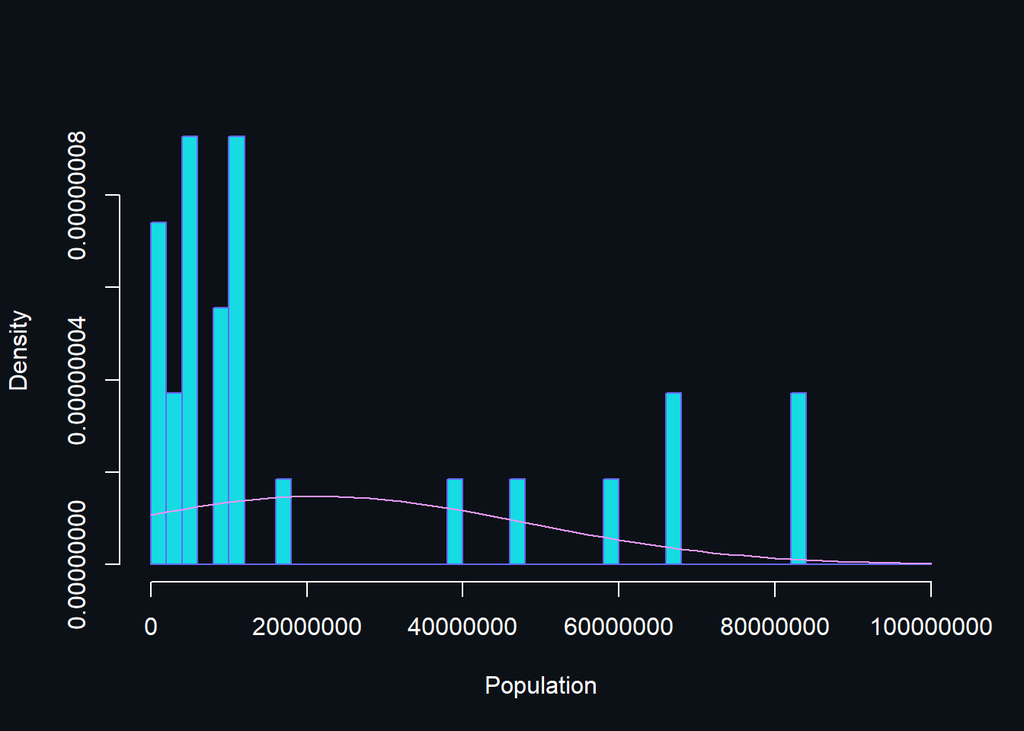

```r
options(scipen = 999)

par(bg = "#0c1117")
hist(data_full$Estimate,
     breaks = seq(0, 100000000, 2000000),
     main = NULL,
     freq = FALSE,
     xlab = "Population",
     col = "#16dbe3",
     border = "#6467ef",
     col.lab = "white",
     col.axis = "white",
     fg = "white")
lines(seq(0, 100000000, 2000000), dnorm(seq(0, 100000000, 2000000),
            mean = mean(data_full$Estimate),
            sd = sqrt(var(data_full$Estimate))),
      col = "#e197f3")
```

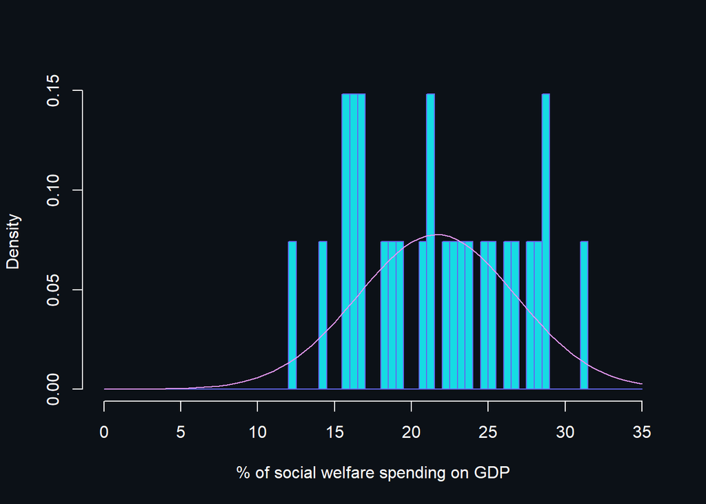

```r
par(bg = "#0c1117")
hist(data_full$Spending,
     breaks = seq(0, 35, 0.5),
     main = NULL,
     freq = FALSE,
     xlab = "% of social welfare spending on GDP",
     col = "#16dbe3",
     border = "#6467ef",
     col.lab = "white",
     col.axis = "white",
     fg = "white")
lines(seq(0, 35, 0.5), dnorm(seq(0, 35, 0.5),
            mean = mean(data_full$Spending),
            sd = sqrt(var(data_full$Spending))),
      col = "#e197f3")
```

Neither population nor spending are normally distributed. Thus, I will be careful with the choice of tests I apply.

## Bivariate analysis

I will now plot the two variables against each other to understand their relationship.

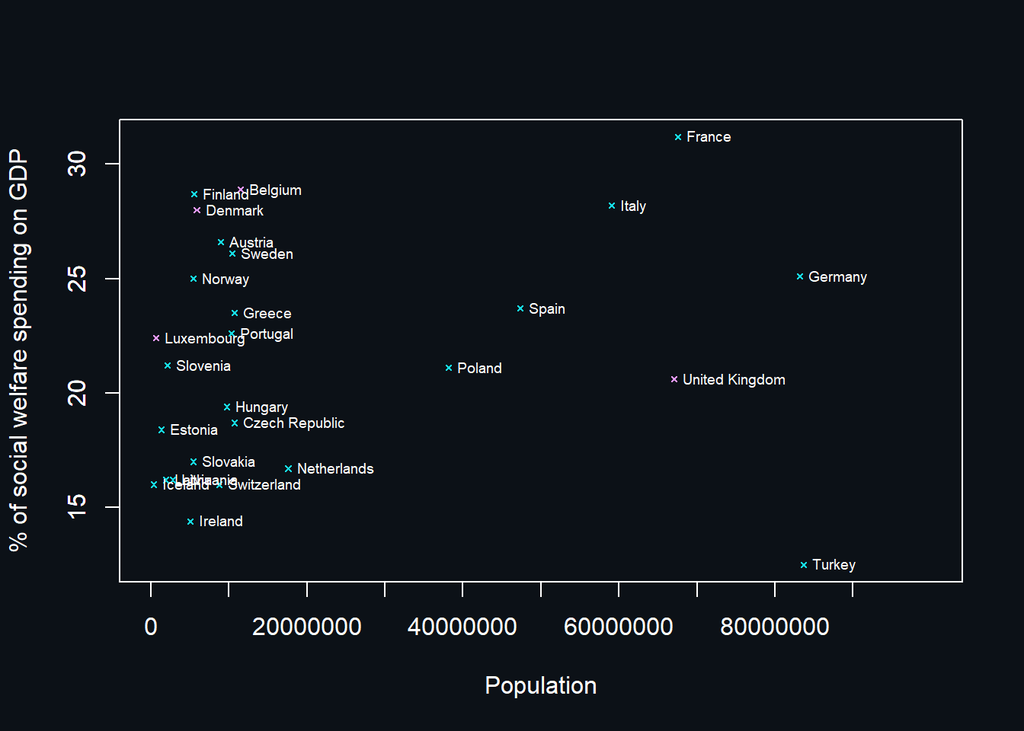

```r
attach(data$full)
par(bg = "#0c1117")
plot(data_full$Estimate, data_full$Spending,
     col = ifelse((data_full == "Denmark") | (data_full == "Luxembourg") | (data_full == "Belgium") | (data_full == "United Kingdom"), "#e197f3", "#16dbe3"),
     col.axis = 'white', col.lab = 'white',
     pch = 4,
     cex = 0.5,
     xlab = "Population", ylab = "% of social welfare spending on GDP",
     xlim = c(0, 100000000),
     xaxt = "n")
axis(side = 2, col = "white", col.axis = "white")
axis(side = 1, at = seq(0, 90000000, 10000000), las = 1, col = "white", col.axis = "white")
box(col="white")
text(data_full$Estimate, data_full$Spending, data_full$Country,
     pos = 4,
     offset = 0.3, cex = 0.6, col = "white")
```

```r
cor(data_full$Estimate,data_full$Spending)
```

```
## [1] 0.1601118
```

I will now focus on the data points which lay inside the cluster of small population sizes.

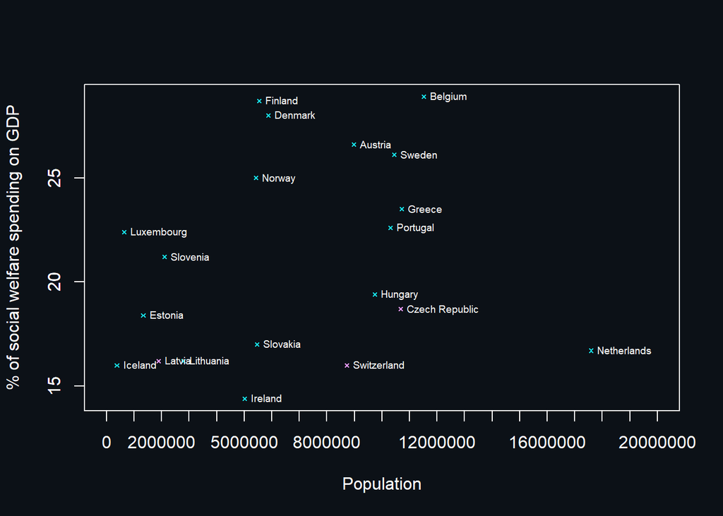

```r
attach(data$full)
par(bg = "#0c1117")
plot(data_full$Estimate[data_full$Estimate < 20000000], data_full$Spending[data_full$Estimate < 20000000],
     col = ifelse((data_full == "Denmark") | (data_full == "Luxembourg") | (data_full == "Belgium") | (data_full == "United Kingdom"), "#e197f3", "#16dbe3"),
     col.axis = 'white', col.lab = 'white',
     pch = 4,
     cex = 0.5,
     xlab = "Population", ylab = "% of social welfare spending on GDP",
     xlim = c(0, 20000000),
     xaxt = "n")
axis(side = 2, col = "white", col.axis = "white")
axis(side = 1, at = seq(0, 20000000, 1000000), las = 1, col = "white", col.axis = "white")
box(col="white")
text(data_full$Estimate[data_full$Estimate < 20000000], data_full$Spending[data_full$Estimate < 20000000], data_full$Country[data_full$Estimate < 20000000],
     pos = 4,
     offset = 0.3, cex = 0.6, col = "white")
```

```r
cor(data_full$Estimate[data_full$Estimate < 20000000],data_full$Spending[data_full$Estimate < 20000000])
```

```
## [1] 0.2131324
```

# I will continue to work on this.